# Meta profile analysis of Rrm4 crosslink signal across stop codon

Author

Srimeenakshi Sankaranarayanan

Published

June 12, 2026

Previosly, Rrm4 was shown to bind specifically at the stop codon, suggesting a link between RNA transport and translation. Here, I will assess whether the improved iCLIP2 protocol detects stop-codon binding with higher efficiency than the previous iCLIP protocol used in Olgeiser et.al (2019).

```r
# Libraries
library(BSgenome.Umaydis.ENSMBL.UM1) # forged tomato genome
library(ggplot2)
library(BindingSiteFinder)
library(rtracklayer)
library(ComplexHeatmap)
library(GenomicFeatures)
library(forcats)
library(tidyr)
library(dplyr)
library(tidyverse)
library(GenomicRanges)
library(magick)
library(magrittr)
library(gridExtra)
library(IRanges)
library(Biostrings)
library(ggrepel)
library(ggpubr)
library(viridis)
library(reshape2)
library(gprofiler2)
library(ggsci)
```

```r
## theme for ggplot
my_theme = theme_set(theme_bw() +
          theme(axis.text = element_text(size = 10, colour="black"),
                axis.title = element_text(size=12, colour="black"),
                axis.ticks=element_line(color="black"),
                axis.ticks.length=unit(.15, "cm"),
                panel.border=element_rect(color="black", fill = NA),
                panel.background = element_blank(),
                plot.background = element_blank(),
                legend.text = element_text(size=10),
                legend.position = "bottom",
                aspect.ratio = 1/1)
)
```

```r
## load gene annotation
gnsN = readRDS("~/Documents/Bioinfo_analysis/iCLIP_course/diffRNA_binding/Annotation_preparation/gns.rds")

trl = readRDS("~/Documents/Bioinfo_analysis/iCLIP_course/diffRNA_binding/Annotation_preparation/trl.rds")
```

```r
## Load binding sites
ic2_bs = import("~/Documents/Bioinfo_analysis/iCLIP_course/iCLIP2_Methods_Stoffel_etal_2023/Rrm4_BS_9nt.bed", format="bed")
ic2_bs = resize(ic2_bs, fix="center", width = 1) # resize to center
```

```r
## import crosslink signals from iCLIP1 (olgeiset et.al 2019)
my.path.iclip1 = "~/Documents/Bioinfo_analysis/iCLIP_course/iCLIP2_Methods_Stoffel_etal_2023/iCLIP1/bw"
# plus strand
plus_bw_i1 = list.files(my.path.iclip1, pattern="Rrm4G_plus", full.names = T)
plus_bw_i1 = import(plus_bw_i1, as= "Rle")
# minus strand
minus_bw_i1 = list.files(my.path.iclip1, pattern="Rrm4G_minus", full.names = T)
minus_bw_i1 = import(minus_bw_i1, format="bw")
# make a list
iCLIP1 = list(plus_ic1 = plus_bw_i1,
                minus_ic1 = minus_bw_i1) %>% as("GRangesList")
```

It is important to note that the `Ensembl` gene annotation label chromosomes numerically, whereas the manually curated annotation used in Olgeiser. et al names chromosome as `Um_chrN`, where N represents the chromosome number. To enable comparison between the two iCLIP dataset, I will remove the `Um_chr` prefix from the chromosome name.

```r
# change the chromosome names
iCLIP1_bw_mod = lapply(iCLIP1, function(i){
  # change Um_chr0
  seqlevels(i) = sub("Um_chr0", "", seqlevels(i))
  # change Um_chr
  seqlevels(i) = sub("Um_chr", "", seqlevels(i))

  # change Um_chr
  seqlevels(i) = sub("Um_scaf", "um_scaf", seqlevels(i))

  return(i)
})

# calculate coverage
iCLIP1_bw_mod = lapply(iCLIP1_bw_mod, function(i){
  cov = coverage(i, weight=i$score)
  return(cov)
})
```

```r
## Import crosslink signals produced from iCLIP2
my.path.iclip2 = "~/Documents/Bioinfo_analysis/iCLIP_course/datasets/imb_koenig_2021_11_stoffel_iCLIP_ustilago_Rrm4/merged/bw"
# in plus strand
plus_bw_i2 = list.files(my.path.iclip2, pattern="Rrm4G.v3.duprm.plus.bw", full.names = T)
plus_bw_i2 = import(plus_bw_i2, as = "Rle")


# in minus strand
minus_bw_i2 = list.files(my.path.iclip2, pattern="Rrm4G.v3.duprm.minus.bw", full.names = T)
minus_bw_i2 = import(minus_bw_i2, as="Rle")
```

```r
## combine the iCLIP data within a list
cl_Rle = list(iC1_p = iCLIP1_bw_mod$plus_ic1,
              iC1_m = iCLIP1_bw_mod$minus_ic1,
              iC2_p = plus_bw_i2,
              iC2_m = minus_bw_i2)
```

```r
## get the window around stop codon
# get protein coding gene alson
gnsNP = gnsN[gnsN$gene_biotype=="protein_coding",]

# collect the stop ntd position
stops= flank(gnsNP, -303,start = FALSE) %>% flank(.,-3)

# get the last nucleotide of stop codon
stops = flank(stops,-1, start=FALSE)
# sanity check 2
#getSeq(Umaydis,stops)

# make stop window
stops = stops+30
```

iCLIP signal across the selected window will be normalized using `min-max normalization` as described in Molitor et al. (2022).

```r
# normalization of iCLIP signal was carried out as described in Molitor et.al 2022
min_max_noramlize <- function(x){
  x_new <- (x-min(x)) / (max(x)-min(x))
  return(x_new)
}
```

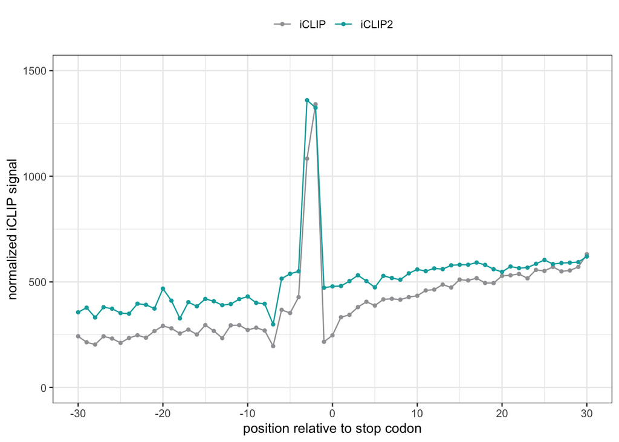

```r
## create a metaprofile
# get the crosslinks within the stop window
cl_Win =  c(map(cl_Rle[c(1,3)],~.x[stops[strand(stops)=="+"]] %>% as.matrix()),
            map(cl_Rle[c(2,4)], ~.x[stops[strand(stops)=="-"]] %>% as.matrix()  %>% .[,ncol(.):1]))

cl_win_bin = list(ic1= rbind(cl_Win$iC1_p, cl_Win$iC1_m),
                  ic2=rbind(cl_Win$iC2_p, cl_Win$iC2_m))

# normalize
cl_win_norm = lapply(cl_win_bin, function(i) apply(i,1, min_max_noramlize) %>% t(.))

# sum of the signal at each poition for each experiment
meta_prof_sum = data.frame(ic1= colSums(cl_win_norm$ic1, na.rm=T),
                           ic2 = colSums(cl_win_norm$ic2, na.rm=T),
                           pos = -floor(ncol(cl_win_norm[[1]])/2): floor(ncol(cl_win_norm$ic1)/2))

meta_profiles_sum_gg <- meta_prof_sum %>% reshape2::melt(id.vars = "pos")

pl = ggplot(meta_profiles_sum_gg, aes(x =pos, y = value, color = variable))+
  geom_line(linewidth=0.5)+
  geom_point(size=1)+
  scale_color_manual(values=c("#A0A0A4", "#00AAAA"), labels = c("iCLIP", "iCLIP2"))+
  labs(x="position relative to stop codon",
       y="normalized iCLIP signal")+
  ylim(0,1500)+
  scale_x_continuous(breaks=seq(-30,30, 10))+
  theme_bw()+
  theme(legend.title = element_blank(), legend.position = "top")

pl
```

```r
## ggsave
#ggsave("C:/Users/Sri/Documents/Bioinfo_analysis/iCLIP_course/iCLIP2_Methods_Stoffel_etal_2023/metaprofile.pdf", pl,  width = 10, height = 10, units ="cm")
```